# EPID 600 Project - Association between health behavior factors and Internet use to obtain health information

Meijia Zhou

Use this template to complete your project throughout the course. Your Final Project presentation in class will be based on the contents of this document. Due dates:

- Topic choice: 9/18/15
- List of faculty/staff to be contacted: 10/2/15
- Complete overview with data source to address a specific problem identified: 10/16/15
- Introduction: 10/30/15
- Methods and Results draft: 11/13/15
- Final Document: 11/30/15

### Overview

In this section, give a brief a description of your project and its goal, what data you are using to complete it, and what three faculty/staff in different fields you have spoken to about your project with a brief summary of what you learned from each person.

Increasing number of people are using Internet to obtain health informtion. Characterization of the population using Internet to obtain health information would help researchers to understand the population, facilitate health information dissemination through Internet and/or develop programs that better targets the population. The objective of this project is to identify health behavior factors associated with using Internet to obtain health information. Specifically, this project is to determine whether smoking status and alcohol drinking status are associated with Internet use to get health information using 2014 National Health Interview Survey (NHIS) Data [http://www.cdc.gov/nchs/nhis/nhis_2014_data_release.htm]. I spoke with three faculty members/fellows and received very helpful insights/advices from them. Dr. Young Hee Nam, Postdoc research fellow at Department of Clinical Epidemiology and Biostatistics, who had background in health policy and management provided me information on regulatory aspects on health information available on the Internet. She also gave me lots of information on this topic in general, including recent relevant publications on this topic and many good resources/websites to look for additional information. I also met with Dr. Ashkan Ertefaie at Department of Statistics in Wharton School of Business for advices on the statistical methods including how to build the models, covariate selection and methods to adjust for the sampling design of NHIS using weights in R. Dr. Haochang Shou, Assistant Professor of Biostatistics at Department of Clinical Epidemiology and Biostatistics also gave me advices on methods of building models, methods to make group comparisons and graphical presentation of data. I acknowledge them for all their help/advices on this project.

Link to the Github repository of this project: https://github.com/meijiazhou/Finalproject

### Introduction

Internet use had changed our lives dramatically in the past several decades. In 2014, 87% of U.S adults use Internet(1), while 72% of Internet users claim use of Internet to obtain health information (2). The increasing trend in use of Internet to seek health information had been observed in other countries as well (3) . Internet offers an alternative approach for individuals to obtain health information when needed. Studies suggested that Internet use facilitates improvement in health outcomes by making more health information available and easily accessible, giving social support, improving self-efficacy of the subject as well as facilitating interactions between patients and the healthcare system (4,5). Despite patients, Internet is also being used by increasing number of researchers and/or healthcare providers to collect information from individuals, to provide healthcare through emails or web-based interfaces, and to implement health interventions through online programs. Internet-based intervention programs to promote health behavior change had shown small but clinically significant effectiveness (6-9). As prevalence of access to Internet continues to increase among the general population, it is important to understand who are using the Internet to search for health information, why and how they are using it. Understanding the target population would facilitate dissemination of useful health information to patients and improved efficacy of the Internet based systems. This study is to investigate the relationship between health behavior factors and use of the Internet to obtain health information using National Health Interview Survey (NHIS), a large national representative cross-sectional survey.

NHIS is a large survey that provides a broad range of information on the health of the civilian non-institutionalized population in the United States. The data is widely used by epidemiologist to monitor disease and disability trends as well as the progress of achieving national health objectives. Health policy researchers also utilize it to evaluate health programs and to identify barriers of access to care. The survey is designed using epidemiologic methods and epidemiologic methods are needed to build the model to answer the research question of interest for this project. Bio-statistical methods are needed to analyze such large samples, to account for the complex multi-stage sampling design of NHIS as well as to ensure correct statistical models are build. Background information on the current status of this general topic is provided largely by joint efforts of epidemiologists, health policy researchers and health behavior researchers. For example, relationship between use of Internet to access health information and access to care was analyzed by health policy researchers based on the hypothesis that subjects had difficulties with access to care may switch to Internet to obtain health information when needed(10). The result of this study could also be useful for health behavior researches to design targeted Internet-based intervention programs to promote health behavior changes.

### Methods

Exposure The exposure of interest are two behavior variables captured in the NHIS database, including the following: smoking status and alcohol drinking status.

Smoking status was measured as current every day smoker, current some day smoker, former smoker, never smoker, and smoker (with current status unknown), and unknown if ever smoked. Subjects with unknown status [i.e smoker (with current status unknown), and unknown if ever smoked)] were removed from the analysis.

Alcohol consumption was originally measured as lifetime abstainer, former infrequent, former regular, former (unknown frequency), current infrequent, current light, current moderate, current heavier, current drinker (frequency/level unknown), and drinking status unknown. Subjects with unknown frequency or unknown alcohol drinking status were removed from the analyis. Then the alcohol drinking status is regrouped into four categories: lifetime abstainer, former drinker, current infrequent-light drinker, and current moderate-heavier drinker.

Outcome The outcome of interest is use of Internet to look up health information. The NHIS 2014 includes the following questions that captured computer use to obtain health information by the interviewees. 1) During the past 12 months, have you ever used computer to look up health information on the Internet? 2) During the past 12 months, have you ever used computer to use online chat groups to learn about health topics? The answer to both questions were recorded as yes or no. People who refused to answer the questions or with unknown responses to these questions were dropped from the analysis. The outcome of interest for this study was a composite outcome of the two outcome measures described above.

Covariates Several covariates were included in the analysis including age, sex, race/ethnicity, marital status, body mass index (BMI), education level, geographical region of residence and general health status. Age and BMI was recorded as continous variables and were categorized in this study.

Statistical method Weighted percentages within each level of covariates seperated by use of Internet to obtain health information were calculated. Demographics and general health status of the interviewees were compared using Chi-squared test between people who used computers to obtain health information and those who did not. Logistic regression was used to estimate the crude and adjusted odds ratio comparing people used computer to obtain health information versus those who did not. In the multivariate models for each health behavior factor, we adjusted for age, sex, race, education level, martial status, BMI, geographical region of residence and general health status. The annual adjusted weights were applied to all the regression models to account for the multistage sampling design and oversampling of the minorities. All the analysis were conducted using R.

```r
# Input NHIS2014 adult data in dta format
# The original NHIS 2014 data was in ASCII format. NHIS provided sample STATA code to read in the data, add labels and convert it to dta format. The sample STATA code was ran to convert ASCII data into dta format. The sample adult data was merged with person data, and then only sample adults' records were kept in the dataset. This new dataset is saved as "data2014.dta"
# Use foreign package to import dta data
library(foreign)
mydata <- read.dta("/Users/meijiazhou/Documents/2015 Fall/EPID 600 Data Science/Final project/data2014.dta")
str(mydata)
```

[output not shown]

[output cut: 253 more lines]

[output not shown]

```r
# There were 36697 observations and 1411 variables in the original dataset
# The dataset shared on Github is a subset of 'mydata', but contains more variables than those included for this analysis.

## Create a dataset with all the variables of interest called "my.data"
my.data<-subset(mydata, select=c(wtia_sa, region, strat_p, psu_p, sex, racerpi2, age_p, r_maritl, proxysa, educ1, phstat, smkstat2, alcstat, bmi, hit1a, hit5a))
str(my.data)
```

```
## 'data.frame':    36697 obs. of  16 variables:
##  $ wtia_sa : num  23313 3300 3482 9990 6046 ...
##  $ region  : Factor w/ 4 levels "1 Northeast",..: 3 2 4 4 3 4 2 4 2 1 ...
##  $ strat_p : num  158 78 282 256 138 275 105 286 114 40 ...
##  $ psu_p   : num  2 2 1 2 2 2 2 1 2 1 ...
##  $ sex     : Factor w/ 2 levels "1 Male","2 Female": 1 2 2 1 1 2 2 1 1 2 ...
##  $ racerpi2: Factor w/ 6 levels "01 White only",..: 1 1 1 1 1 1 1 1 1 1 ...
##  $ age_p   : num  62 69 85 20 25 36 42 50 36 79 ...
##  $ r_maritl: Factor w/ 10 levels "0 Under 14 years",..: 8 5 5 8 8 2 2 10 2 5 ...
##  $ proxysa : Factor w/ 3 levels "1 Physical or mental condition prohibits responding",..: 2 2 2 2 2 2 2 2 2 2 ...
##  $ educ1   : Factor w/ 26 levels "00 Never attended/kindergarten only",..: 26 20 15 16 16 19 16 16 15 15 ...
##  $ phstat  : Factor w/ 8 levels "1 Excellent",..: 2 1 1 1 1 3 3 3 2 1 ...
##  $ smkstat2: Factor w/ 6 levels "1 Current every day smoker",..: 4 4 4 4 4 4 4 4 4 4 ...
##  $ alcstat : Factor w/ 10 levels "01 Lifetime abstainer",..: 1 6 5 7 6 1 1 5 6 5 ...
##  $ bmi     : num  20.5 25.8 30 23.1 25.1 ...
##  $ hit1a   : Factor w/ 5 levels "1 Yes","2 No",..: 1 2 2 2 2 2 1 2 1 2 ...
##  $ hit5a   : Factor w/ 5 levels "1 Yes","2 No",..: 2 2 2 2 2 2 2 2 2 2 ...
```

```r
# my.data has 36697 observations and 16 variables.

library(dplyr)
## Data cleaning ##
# Mark people who answered the question by an proxy or with unknown status and coded their responses as "NA". So we can only keep the records for those who answered the questions by themselves in the analysis.
table(my.data$proxysa)
```

```
##
## 1 Physical or mental condition prohibits responding
##                                                 488
##                   2 Sample adult is able to respond
##                                               35681
##                                           3 Unknown
##                                                 528
```

```r
my.data <- my.data  %>%
    mutate(proxysa = ifelse(as.numeric(proxysa)==1, NA, proxysa)) %>%
    mutate(proxysa = ifelse(as.numeric(proxysa)==3, NA, proxysa))
table(my.data$proxysa)
```

```
##
##     2
## 35681
```

```r
## Prepare the analytic dataset for complete case analysis - look into each variable of interest and code the categories with missing data, with responses of unknown status, or with incomplete responses as "NA". For example, subjects who refused to answer the question, or former alcohol drinker with unknown frequency.
# Outcome variable - Use of Internet to obtain health information
# 1) Use of internet to look for health info?
table(my.data$hit1a)
```

```
##
##             1 Yes              2 No         7 Refused 8 Not ascertained
##             14783             21356                27               504
##   9 Don\x92t know
##                27
```

```r
my.data <- my.data  %>%
    mutate(hit1a = ifelse(as.numeric(hit1a)==3, NA, hit1a)) %>%
    mutate(hit1a = ifelse(as.numeric(hit1a)==4, NA, hit1a)) %>%
    mutate(hit1a = ifelse(as.numeric(hit1a)==5, NA, hit1a))
my.data$hit1a<-factor(my.data$hit1a, labels=c("Yes", "No"))
new.levels<-c(1,0)
my.data$hit1a<-factor(new.levels[my.data$hit1a])
my.data$hit1a<-factor(my.data$hit1a, labels=c("No", "Yes"))
table(my.data$hit1a)
```

```
##
##    No   Yes
## 21356 14783
```

```r
# 2) Use of online chat groups to learn about health topics?
table(my.data$hit5a)
```

```
##
##             1 Yes              2 No         7 Refused 8 Not ascertained
##               907             35236                27               516
##   9 Don\x92t know
##                11
```

```r
my.data <- my.data  %>%
    mutate(hit5a = ifelse(as.numeric(hit5a)==3, NA, hit5a)) %>%
    mutate(hit5a = ifelse(as.numeric(hit5a)==4, NA, hit5a)) %>%
    mutate(hit5a = ifelse(as.numeric(hit5a)==5, NA, hit5a))
new.levels<-c(1,0)
my.data$hit5a<-factor(new.levels[my.data$hit5a])
my.data$hit5a<-factor(my.data$hit5a, labels=c("No", "Yes"))
table(my.data$hit5a)
```

```
##
##    No   Yes
## 35236   907
```

```r
# Create a new variable for the composite outcome of the two variables above
my.data$hit1a<-as.numeric(my.data$hit1a)
my.data$hit5a<-as.numeric(my.data$hit5a)
my.data$outcome<-(my.data$hit1a + my.data$hit5a)
my.data$outcome<-as.factor(my.data$outcome)
table(my.data$outcome)
```

```
##
##     2     3     4
## 21273 14013   835
```

```r
# assign new levels and add labels to the new outcome variable
new.levels<-c(0,1,1)
my.data$outcome<-factor(new.levels[my.data$outcome])
my.data$outcome<-factor(my.data$outcome, labels=c("No", "Yes"))
table(my.data$outcome)
```

```
##
##    No   Yes
## 21273 14848
```

```r
## Exposure of interests
# Smoking status
levels(my.data$smkstat2)
```

```
## [1] "1 Current every day smoker"       "2 Current some day smoker"
## [3] "3 Former smoker"                  "4 Never smoker"
## [5] "5 Smoker, current status unknown" "9 Unknown if ever smoked"
```

```r
table(my.data$smkstat2)
```

```
##
##       1 Current every day smoker        2 Current some day smoker
##                             4858                             1520
##                  3 Former smoker                   4 Never smoker
##                             8281                            21838
## 5 Smoker, current status unknown         9 Unknown if ever smoked
##                               13                              187
```

```r
my.data <- my.data  %>%
    mutate(smkstat2 = ifelse(as.numeric(smkstat2)==5, NA, smkstat2)) %>%
    mutate(smkstat2 = ifelse(as.numeric(smkstat2)==6, NA, smkstat2))
my.data$smkstat2<-factor(my.data$smkstat2, labels=c("current every day smoker", "current some day smoker", "former smoker", "never smoker"))
# Assign new levels
new.levels<-c(3,2,1,0)
my.data$smkstat2<-factor(new.levels[my.data$smkstat2])
my.data$smkstat2<-factor(my.data$smkstat2, labels=c("never smoker", "former smoker", "current some day smoker", "current every day smoker"))
table(my.data$smkstat2)
```

```
##
##             never smoker            former smoker  current some day smoker
##                    21838                     8281                     1520
## current every day smoker
##                     4858
```

```r
# Alcohol consumption
levels(my.data$alcstat)
```

```
##  [1] "01 Lifetime abstainer"
##  [2] "02 Former infrequent"
##  [3] "03 Former regular"
##  [4] "04 Former, unknown frequency"
##  [5] "05 Current infrequent"
##  [6] "06 Current light"
##  [7] "07 Current moderate"
##  [8] "08 Current heavier"
##  [9] "09 Current drinker, frequency/level unknown"
## [10] "10 Drinking status unknown"
```

```r
table(my.data$alcstat)
```

```
##
##                       01 Lifetime abstainer
##                                        7634
##                        02 Former infrequent
##                                        3199
##                           03 Former regular
##                                        2381
##                04 Former, unknown frequency
##                                           6
##                       05 Current infrequent
##                                        4617
##                            06 Current light
##                                       10766
##                         07 Current moderate
##                                        5482
##                          08 Current heavier
##                                        1922
## 09 Current drinker, frequency/level unknown
##                                         129
##                  10 Drinking status unknown
##                                         561
```

```r
my.data <- my.data  %>%
    mutate(alcstat = ifelse(as.numeric(alcstat)==4, NA, alcstat)) %>%
    mutate(alcstat = ifelse(as.numeric(alcstat)==9, NA, alcstat)) %>%
    mutate(alcstat = ifelse(as.numeric(alcstat)==10, NA, alcstat))
my.data$alcstat<-factor(my.data$alcstat, labels=c("Lifetime abstainer", "Former infrequent", "Former regular", "Current infrequent", "Current light", "Current moderate", "Current heavier"))
new.levels<-c(0,1,2,3,4,5,6)
my.data$alcstat<-factor(new.levels[my.data$alcstat])
my.data$alcstat<-factor(my.data$alcstat, labels=c("Lifetime abstainer", "Former infrequent", "Former regular", "Current infrequent", "Current light", "Current moderate", "Current heavier"))
table(my.data$alcstat)
```

```
##
## Lifetime abstainer  Former infrequent     Former regular
##               7634               3199               2381
## Current infrequent      Current light   Current moderate
##               4617              10766               5482
##    Current heavier
##               1922
```

```r
# Re-group as "Lifetime abstainer", "Former drinker", "Current infrequent-light drinker", "Current moderate-heavier drinker"
my.data$alcstat2<-my.data$alcstat
new.levels<-c(0,1,1,2,2,3,3)
my.data$alcstat2<-factor(new.levels[my.data$alcstat2])
my.data$alcstat2<-factor(my.data$alcstat2, labels=c("Lifetime abstainer", "Former drinker", "Current infrequent-light drinker", "Current moderate-heavier drinker"))
table(my.data$alcstat2)
```

```
##
##               Lifetime abstainer                   Former drinker
##                             7634                             5580
## Current infrequent-light drinker Current moderate-heavier drinker
##                            15383                             7404
```

```r
## Covariates of interest
# a) Continuous variable (age and bmi): look at the summary statistics/distribution of each variable, create new categorical variables
# b) Categorical variables: remove data for subjects with unknown status (i.e change it to NA), re-classify the groups and assign new levels when needed (eg: marital status, education level, and race)
## Demographics:
# Age(age_p) - summary statistics for age
summary(my.data$age_p)
```

```
##    Min. 1st Qu.  Median    Mean 3rd Qu.    Max.
##    18.0    34.0    49.0    49.3    64.0    85.0
```

```r
# Categorized age into three groups: 18-45, 46-65, 65+ years
my.data$agecat<-cut(my.data$age_p, breaks=c(18, 45, 65, Inf), labels=c("18-45", "46-65", "65+"))
table(my.data$agecat)
```

```
##
## 18-45 46-65   65+
## 15933 12371  8020
```

```r
# Gender(sex)
table(my.data$sex)
```

```
##
##   1 Male 2 Female
##    16398    20299
```

```r
# Marital status (r_maritl) - Recode those with unknown status as "NA""
table(my.data$r_maritl)
```

```
##
##                        0 Under 14 years
##                                       0
##         1 Married - spouse in household
##                                   15424
##     2 Married - spouse not in household
##                                     624
## 3 Married - spouse in household unknown
##                                       0
##                               4 Widowed
##                                    3480
##                              5 Divorced
##                                    5184
##                             6 Separated
##                                    1044
##                         7 Never married
##                                    8602
##                   8 Living with partner
##                                    2253
##                9 Unknown marital status
##                                      86
```

```r
my.data <- my.data  %>%
    mutate(r_maritl = ifelse(as.numeric(r_maritl)==1, NA, r_maritl)) %>%
    mutate(r_maritl = ifelse(as.numeric(r_maritl)==10, NA, r_maritl))
my.data$r_maritl<-factor(my.data$r_maritl)
table(my.data$r_maritl)
```

```
##
##     2     3     5     6     7     8     9
## 15424   624  3480  5184  1044  8602  2253
```

```r
levels(my.data$r_maritl)
```

```
## [1] "2" "3" "5" "6" "7" "8" "9"
```

```r
# Categorized marital status into new groups: Never Married, Married/Living with Partner, Divorced/Seperated, Widowed
new.levels<-c(1,1,3,2,2,0,1)
my.data$r_maritl<-factor(new.levels[my.data$r_maritl])
my.data$r_maritl<-factor(my.data$r_maritl, labels=c("Never Married", "Married/Living with Partner", "Divorced/Seperated", "Widowed"))
levels(my.data$r_maritl)
```

```
## [1] "Never Married"               "Married/Living with Partner"
## [3] "Divorced/Seperated"          "Widowed"
```

```r
table(my.data$r_maritl)
```

```
##
##               Never Married Married/Living with Partner
##                        8602                       18301
##          Divorced/Seperated                     Widowed
##                        6228                        3480
```

```r
# Region(region)
table(my.data$region)
```

```
##
## 1 Northeast   2 Midwest     3 South      4 West
##        5919        7809       12896       10073
```

```r
# Race(racerpi2)
table(my.data$racerpi2)
```

```
##
##                                  01 White only
##                                          28209
##                 02 Black/African American only
##                                           5173
##                                   03 AIAN only
##                                            377
##                                  04 Asian only
##                                           2129
## 05 Race group not releasable (See file layout)
##                                             75
##                               06 Multiple race
##                                            734
```

```r
levels(my.data$racerpi2)
```

```
## [1] "01 White only"
## [2] "02 Black/African American only"
## [3] "03 AIAN only"
## [4] "04 Asian only"
## [5] "05 Race group not releasable (See file layout)"
## [6] "06 Multiple race"
```

```r
# Categorize race into new groups
new.levels<-c(1,2,3,4,5,5)
my.data$racerpi2<-factor(new.levels[my.data$racerpi2])
my.data$racerpi2<-factor(my.data$racerpi2, labels=c("White", "Black/Aferican American", "American Indian Alaska Native", "Asian", "Multiple race/Other"))
levels(my.data$racerpi2)
```

```
## [1] "White"                         "Black/Aferican American"
## [3] "American Indian Alaska Native" "Asian"
## [5] "Multiple race/Other"
```

```r
table(my.data$racerpi2)
```

```
##
##                         White       Black/Aferican American
##                         28209                          5173
## American Indian Alaska Native                         Asian
##                           377                          2129
##           Multiple race/Other
##                           809
```

```r
# BMI - Create categorical variable for bmi and add labels
summary(my.data$bmi)
```

```
##    Min. 1st Qu.  Median    Mean 3rd Qu.    Max.
##    9.33   23.72   27.11   30.53   31.68   99.99
```

```r
my.data$bmicat<-cut(my.data$bmi, breaks=c(0, 18.5, 24.9, 29.9, 35, Inf), labels=c("underweight", "healthy", "overweight", "obese", "morbidly_obese"))
table(my.data$bmicat)
```

```
##
##    underweight        healthy     overweight          obese morbidly_obese
##            658          11685          12222           6546           5586
```

```r
# Education level
table(my.data$educ1)
```

```
##
##                                  00 Never attended/kindergarten only
##                                                                  165
##                                                         01 1st grade
##                                                                   40
##                                                         02 2nd grade
##                                                                   76
##                                                         03 3rd grade
##                                                                  130
##                                                         04 4th grade
##                                                                  117
##                                                         05 5th grade
##                                                                  169
##                                                         06 6th grade
##                                                                  576
##                                                         07 7th grade
##                                                                  215
##                                                         08 8th grade
##                                                                  576
##                                                         09 9th grade
##                                                                  732
##                                                        10 10th grade
##                                                                  824
##                                                        11 11th grade
##                                                                 1019
##                                            12 12th grade, no diploma
##                                                                  840
##                                                 13 GED or equivalent
##                                                                 1143
##                                              14 High School Graduate
##                                                                 8348
##                                           15 Some college, no degree
##                                                                 7152
## 16 Associate degree: occupational, technical, or vocational program
##                                                                 2673
##                                17 Associate degree: academic program
##                                                                 1376
##                      18 Bachelor's degree (Example: BA, AB, BS, BBA)
##                                                                 6549
##                 19 Master's degree (Example: MA, MS, MEng, MEd, MBA)
##                                                                 2828
##            20 Professional School degree (Example: MD, DDS, DVM, JD)
##                                                                  465
##                               21 Doctoral degree (Example: PhD, EdD)
##                                                                  521
##                                           96 Child under 5 years old
##                                                                    0
##                                                           97 Refused
##                                                                   46
##                                                   98 Not ascertained
##                                                                    0
##                                                        99 Don't know
##                                                                  117
```

```r
my.data <- my.data  %>%
    mutate(educ1 = ifelse(as.numeric(educ1)==23, NA, educ1)) %>%
    mutate(educ1 = ifelse(as.numeric(educ1)==24, NA, educ1)) %>%
    mutate(educ1 = ifelse(as.numeric(educ1)==25, NA, educ1)) %>%
    mutate(educ1 = ifelse(as.numeric(educ1)==26, NA, educ1))
table(my.data$educ1)
```

```
##
##    1    2    3    4    5    6    7    8    9   10   11   12   13   14   15
##  165   40   76  130  117  169  576  215  576  732  824 1019  840 1143 8348
##   16   17   18   19   20   21   22
## 7152 2673 1376 6549 2828  465  521
```

```r
# Categorized into new groups: Less than high school, High School/GED, Associate, Bachelor, Graduate degree
new.levels<-c(0,0,0,0,0,0,0,0,0,0,0,0,0,1,1,2,2,2,3,4,4,4)
my.data$educ1<-factor(new.levels[my.data$educ1])
my.data$educ1<-factor(my.data$educ1, labels=c("Less than High School", "High School/GED", "Associate", "Bachelor", "Graduate Degree"))
table(my.data$educ1)
```

```
##
## Less than High School       High School/GED             Associate
##                  5479                  9491                 11201
##              Bachelor       Graduate Degree
##                  6549                  3814
```

```r
## General health status
table(my.data$phstat)
```

```
##
##       1 Excellent       2 Very good            3 Good            4 Fair
##              9625             11594             10086              4104
##            5 Poor         7 Refused 8 Not ascertained      9 Don't know
##              1265                 8                 0                15
```

```r
my.data <- my.data  %>%
    mutate(phstat = ifelse(as.numeric(phstat)==6, NA, phstat)) %>%
    mutate(phstat = ifelse(as.numeric(phstat)==7, NA, phstat)) %>%
    mutate(phstat = ifelse(as.numeric(phstat)==8, NA, phstat))
table(my.data$phstat)
```

```
##
##     1     2     3     4     5
##  9625 11594 10086  4104  1265
```

```r
# Assign new levels
new.levels<-c(0,1,2,3,4)
my.data$phstat<-factor(new.levels[my.data$phstat])
my.data$phstat<-factor(my.data$phstat, labels=c("Excellent", "Very Good", "Good", "Fair", "Poor"))
table(my.data$phstat)
```

```
##
## Excellent Very Good      Good      Fair      Poor
##      9625     11594     10086      4104      1265
```

```r
####  using the survey package to account for the complex design of the NHIS survey
library(survey)
## create svydesign
nhissvy <- svydesign(id=~psu_p, strata=~strat_p, nest=TRUE, weights=~wtia_sa, data=my.data)
nhis.complete <- na.omit(nhissvy)
```

### Results

```r
## Descriptive analysis
## Percentage of subjects in each outcome group
# Distribution of each component of the outcome
a<-svymean( ~interaction(hit5a, hit1a), design=nhissvy, na.rm=TRUE)
b<-ftable(a, rownames=list(hit5a=c("No", "Yes"), hit1a=c("No", "Yes")))
b
```

```
##            hit5a           No          Yes
## hit1a
## No    mean       0.5651341467 0.0016359501
##       SE         0.0041870048 0.0002665905
## Yes   mean       0.4101386985 0.0230912048
##       SE         0.0041397064 0.0010264075
```

```r
# Distribution of the outcome
a<-svymean(~outcome, design=nhissvy, na.rm=TRUE)
a
```

```
##               mean     SE
## outcomeNo  0.56513 0.0042
## outcomeYes 0.43487 0.0042
```

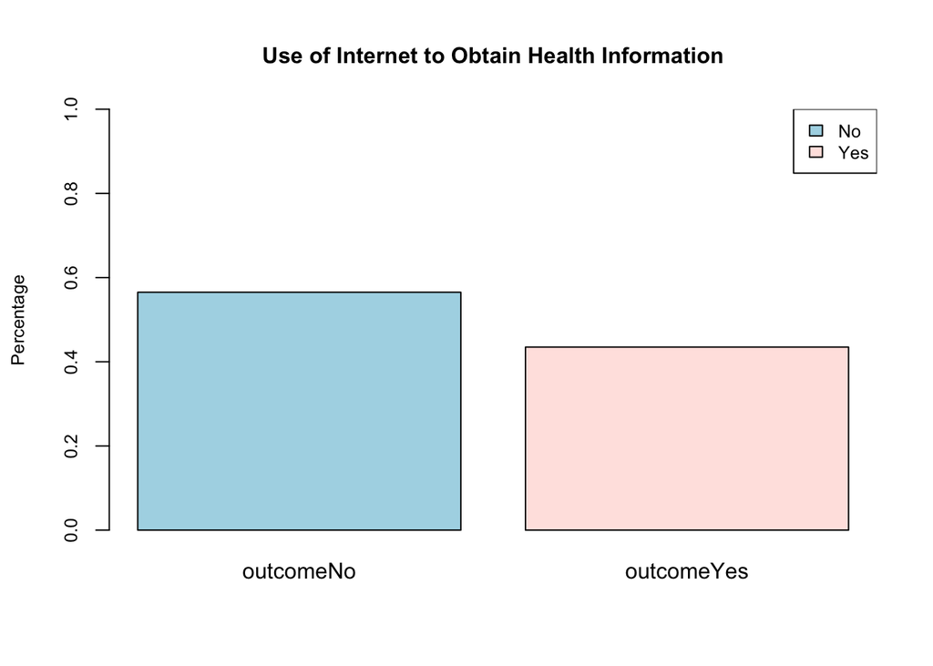

```r
# Plot the percentage of subjects with and without the outcome (i.e use of Internet to obtain health information)
colors<-c("lightblue", "mistyrose")
barplot(a, main="Use of Internet to Obtain Health Information", ylab="Percentage", ylim=c(0.0, 1.0), cex.lab=0.8, cex.main=1.0, cex.axis=0.8, col=colors, space=NULL)
legend("topright", legend=c("No", "Yes"), fill=colors, cex=0.80)
```

```r
## Percentage of people within each categories of independent variables (exposures and covariates) by outcome
## Compare the percentages of people within each categories of the covariate between subjects who reported use of Internet to obtain health information vs. those who did not. Present table of percentages by outcome, plot the distributions and perform Chi squared test for each independent variable.
# Exposures
# Smoking status
a<-svyby( ~smkstat2, ~outcome, nhissvy, svymean, na.rm=TRUE)
a
```

```
##     outcome smkstat2never smoker smkstat2former smoker
## No       No            0.6025899             0.2148001
## Yes     Yes            0.6118154             0.2459819
##     smkstat2current some day smoker smkstat2current every day smoker
## No                       0.03838039                        0.1442297
## Yes                      0.03505075                        0.1071519
##     se.smkstat2never smoker se.smkstat2former smoker
## No              0.004434868              0.003825125
## Yes             0.006033045              0.004830497
##     se.smkstat2current some day smoker se.smkstat2current every day smoker
## No                         0.001834716                         0.003339829
## Yes                        0.001958600                         0.004927127
```

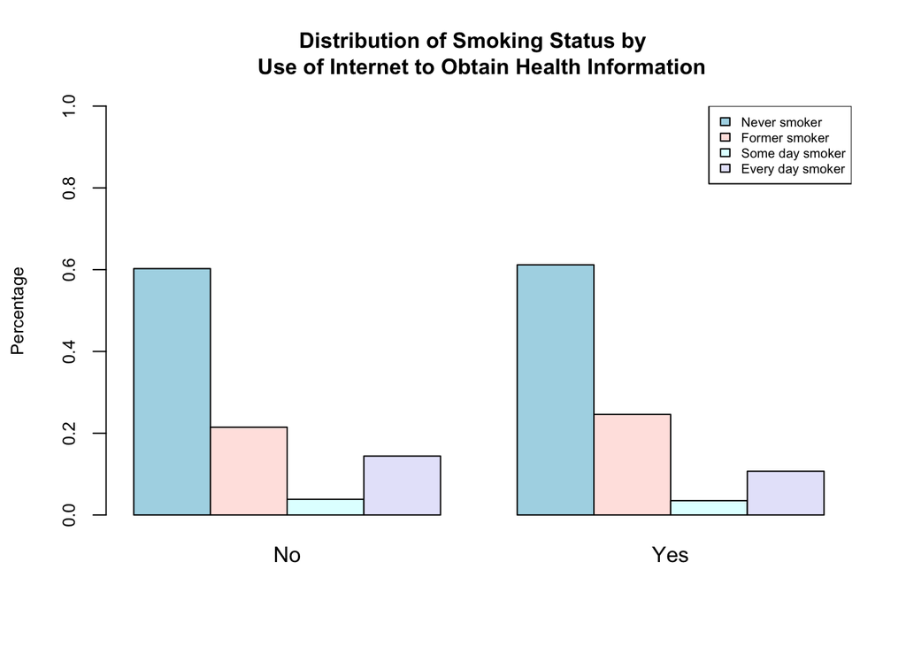

```r
# Plot of smoking status by outcome groups
colors<-c("lightblue", "mistyrose", "lightcyan", "lavender")
barplot(a, beside=TRUE, main="Distribution of Smoking Status by  \n Use of Internet to Obtain Health Information", ylab="Percentage", ylim=c(0.0, 1.0), cex.lab=0.8, cex.main=1.0, cex.axis=0.8, col=colors, space=NULL)
legend("topright", legend=c("Never smoker", "Former smoker", "Some day smoker", "Every day smoker"), fill=colors, cex=0.60)
```

```r
# Chi-squared test
svychisq(~outcome+smkstat2, design=nhissvy)
```

```
##
##  Pearson's X^2: Rao & Scott adjustment
##
## data:  svychisq(~outcome + smkstat2, design = nhissvy)
## F = 22.241, ndf = 2.8101, ddf = 843.0400, p-value = 3.618e-13
```

```r
# Alcohol drinking status
a<-svyby( ~alcstat2, ~outcome, nhissvy, svymean, na.rm=TRUE)
a
```

```
##     outcome alcstat2Lifetime abstainer alcstat2Former drinker
## No       No                  0.2622077              0.1666530
## Yes     Yes                  0.1401612              0.1131769
##     alcstat2Current infrequent-light drinker
## No                                 0.3922156
## Yes                                0.5069113
##     alcstat2Current moderate-heavier drinker se.alcstat2Lifetime abstainer
## No                                 0.1789237                    0.00463578
## Yes                                0.2397506                    0.00461022
##     se.alcstat2Former drinker se.alcstat2Current infrequent-light drinker
## No                0.003472262                                 0.005372590
## Yes               0.003521949                                 0.005644348
##     se.alcstat2Current moderate-heavier drinker
## No                                  0.004060683
## Yes                                 0.005671760
```

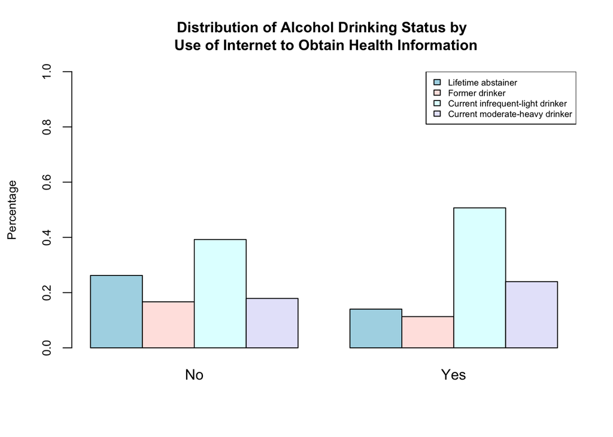

```r
# Plot of alcohol drinking status by outcome groups
colors<-c("lightblue", "mistyrose", "lightcyan", "lavender")
barplot(a, beside=TRUE, main="Distribution of Alcohol Drinking Status by \n Use of Internet to Obtain Health Information", ylab="Percentage", ylim=c(0.0, 1.0), cex.lab=0.8, cex.main=1.0, cex.axis=0.8, col=colors, space=NULL)
legend("topright", legend=c("Lifetime abstainer", "Former drinker", "Current infrequent-light drinker", "Current moderate-heavy drinker"), fill=colors, cex=0.60)
```

```r
# Chi-squared test
svychisq(~outcome+alcstat2, design=nhissvy)
```

```
##
##  Pearson's X^2: Rao & Scott adjustment
##
## data:  svychisq(~outcome + alcstat2, design = nhissvy)
## F = 183.41, ndf = 2.86, ddf = 858.01, p-value < 2.2e-16
```

```r
# Covariates
# Social demographics
# Age groups
colors<-c("lightblue", "mistyrose", "lightcyan")
a<-svyby( ~agecat, ~outcome, nhissvy, svymean, na.rm=TRUE)
a
```

```
##     outcome agecat18-45 agecat46-65 agecat65+ se.agecat18-45
## No       No   0.3972064   0.3467614 0.2560322    0.005050566
## Yes     Yes   0.4980181   0.3724566 0.1295252    0.006434277
##     se.agecat46-65 se.agecat65+
## No     0.004574521  0.004405507
## Yes    0.005711595  0.003885331
```

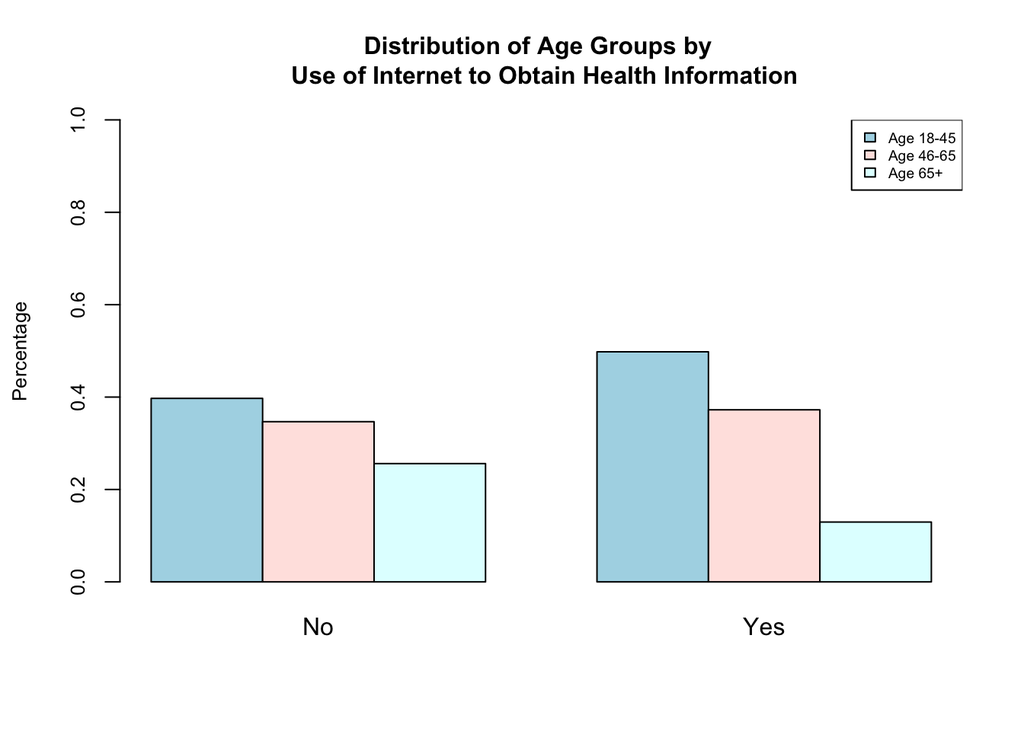

```r
# Plot of age groups by outcome groups
barplot(a, beside=TRUE, main="Distribution of Age Groups by \n Use of Internet to Obtain Health Information", ylab="Percentage", ylim=c(0.0, 1.0), cex.lab=0.8, cex.main=1.0, cex.axis=0.8, col=colors, space=NULL)
legend("topright", legend=c("Age 18-45", "Age 46-65", "Age 65+"), fill=colors, cex=0.60)
```

```r
# Chi-squared test
svychisq(~outcome+agecat, design=nhissvy)
```

```
##
##  Pearson's X^2: Rao & Scott adjustment
##
## data:  svychisq(~outcome + agecat, design = nhissvy)
## F = 290.57, ndf = 1.9885, ddf = 596.5400, p-value < 2.2e-16
```

```r
# Gender
colors<-c("lightblue", "mistyrose")
a<-svyby( ~sex, ~outcome, nhissvy, svymean, na.rm=TRUE)
a
```

```
##     outcome sex1 Male sex2 Female se.sex1 Male se.sex2 Female
## No       No 0.4970279   0.5029721  0.004885523    0.004885523
## Yes     Yes 0.4056226   0.5943774  0.005737883    0.005737883
```

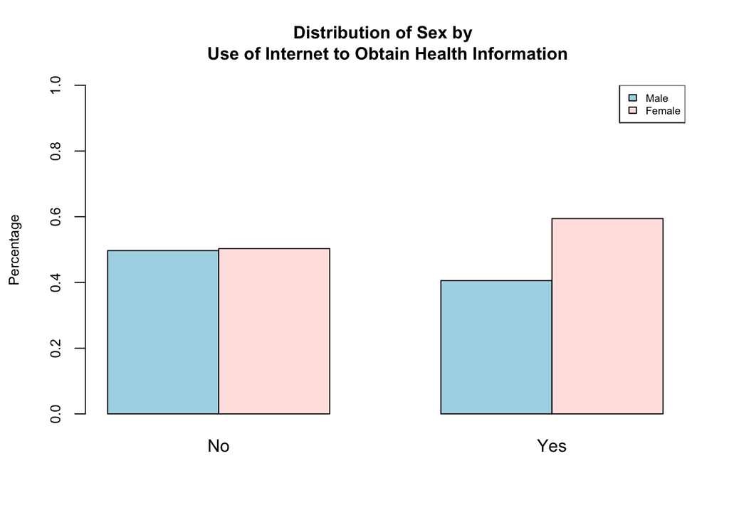

```r
# Plot of gender by outcome groups
barplot(a, beside=TRUE, main="Distribution of Sex by \n Use of Internet to Obtain Health Information", ylab="Percentage", ylim=c(0.0, 1.0), cex.lab=0.8, cex.main=1.0, cex.axis=0.8, col=colors, space=NULL)
legend("topright", legend=c("Male", "Female"), fill=colors, cex=0.60)
```

```r
# Chi-squared test
svychisq(~outcome+sex, design=nhissvy)
```

```
##
##  Pearson's X^2: Rao & Scott adjustment
##
## data:  svychisq(~outcome + sex, design = nhissvy)
## F = 167.57, ndf = 1, ddf = 300, p-value < 2.2e-16
```

```r
# Marital status
a<-svyby( ~r_maritl, ~outcome, nhissvy, svymean, na.rm=TRUE)
a
```

```
##     outcome r_maritlNever Married r_maritlMarried/Living with Partner
## No       No             0.2011169                           0.5789593
## Yes     Yes             0.1968501                           0.6643919
##     r_maritlDivorced/Seperated r_maritlWidowed se.r_maritlNever Married
## No                   0.1224608      0.09746299              0.004168317
## Yes                  0.1083757      0.03038234              0.005175542
##     se.r_maritlMarried/Living with Partner se.r_maritlDivorced/Seperated
## No                             0.005158035                   0.002955894
## Yes                            0.005501007                   0.003081978
##     se.r_maritlWidowed
## No         0.002566361
## Yes        0.001707624
```

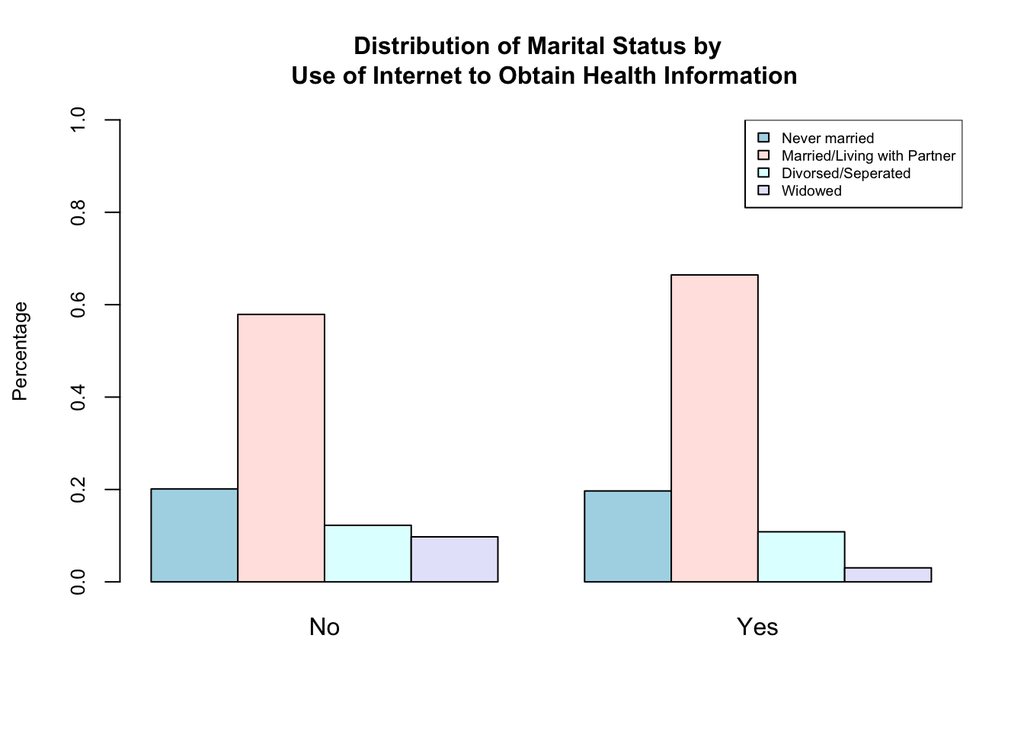

```r
# Plot of marital status by outcome groups
colors<-c("lightblue", "mistyrose", "lightcyan", "lavender")
barplot(a, beside=TRUE, main="Distribution of Marital Status by \n Use of Internet to Obtain Health Information", ylab="Percentage", ylim=c(0.0, 1.0), cex.lab=0.8, cex.main=1.0, cex.axis=0.8, col=colors, space=NULL)
legend("topright", legend=c("Never married", "Married/Living with Partner", "Divorsed/Seperated", "Widowed"), fill=colors, cex=0.60)
```

```r
# Chi-squared test
svychisq(~outcome+r_maritl, design=nhissvy)
```

```
##
##  Pearson's X^2: Rao & Scott adjustment
##
## data:  svychisq(~outcome + r_maritl, design = nhissvy)
## F = 130.52, ndf = 2.7939, ddf = 838.1600, p-value < 2.2e-16
```

```r
# Region
a<-svyby( ~region, ~outcome, nhissvy, svymean, na.rm=TRUE)
a
```

```
##     outcome region1 Northeast region2 Midwest region3 South region4 West
## No       No         0.1740283       0.2200718     0.3927182    0.2131817
## Yes     Yes         0.1747303       0.2441972     0.3430016    0.2380709
##     se.region1 Northeast se.region2 Midwest se.region3 South
## No           0.004519431        0.004635263      0.005729462
## Yes          0.005700833        0.006878959      0.008061826
##     se.region4 West
## No      0.004474768
## Yes     0.006234353
```

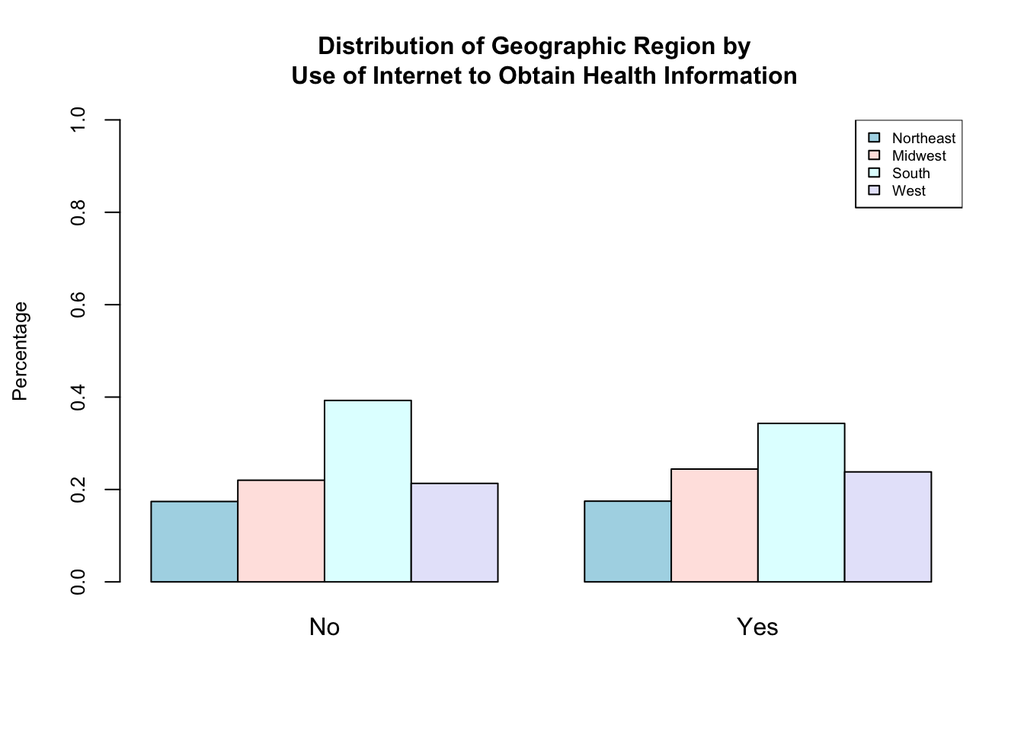

```r
# Plot of region by outcome groups
colors<-c("lightblue", "mistyrose", "lightcyan", "lavender")
barplot(a, beside=TRUE, main="Distribution of Geographic Region by  \n Use of Internet to Obtain Health Information", ylab="Percentage", ylim=c(0.0, 1.0), cex.lab=0.8, cex.main=1.0, cex.axis=0.8, col=colors, space=NULL)
legend("topright", legend=c("Northeast", "Midwest", "South", "West"), fill=colors, cex=0.60)
```

```r
# Chi-squared test
svychisq(~outcome+region, design=nhissvy)
```

```
##
##  Pearson's X^2: Rao & Scott adjustment
##
## data:  svychisq(~outcome + region, design = nhissvy)
## F = 14.184, ndf = 2.9393, ddf = 881.8000, p-value = 6.712e-09
```

```r
# Race/ethnicity
a<-svyby( ~racerpi2, ~outcome, nhissvy, svymean, na.rm=TRUE)
a
```

```
##     outcome racerpi2White racerpi2Black/Aferican American
## No       No     0.7833013                      0.13168286
## Yes     Yes     0.8408796                      0.08537354
##     racerpi2American Indian Alaska Native racerpi2Asian
## No                            0.010124013    0.05954577
## Yes                           0.005440317    0.05002542
##     racerpi2Multiple race/Other se.racerpi2White
## No                   0.01534609      0.004014061
## Yes                  0.01828110      0.004286907
##     se.racerpi2Black/Aferican American
## No                         0.003478296
## Yes                        0.003106072
##     se.racerpi2American Indian Alaska Native se.racerpi2Asian
## No                              0.0013344521      0.002433273
## Yes                             0.0008457837      0.002515154
##     se.racerpi2Multiple race/Other
## No                     0.001148174
## Yes                    0.001450693
```

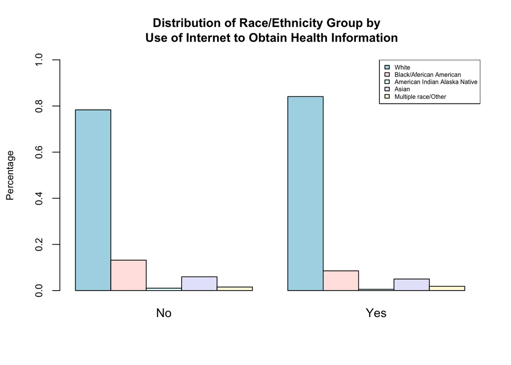

```r
# Plot of race by outcome groups
colors<-c("lightblue", "mistyrose", "lightcyan", "lavender","cornsilk")
barplot(a, beside=TRUE, main="Distribution of Race/Ethnicity Group by  \n Use of Internet to Obtain Health Information", ylab="Percentage", ylim=c(0.0, 1.0), cex.lab=0.8, cex.main=1.0, cex.axis=0.8, col=colors, space=NULL)
legend("topright", legend=c("White", "Black/Aferican American", "American Indian Alaska Native", "Asian", "Multiple race/Other"), fill=colors, cex=0.5)
```

```r
# Chi-squared test
svychisq(~outcome+racerpi2, design=nhissvy)
```

```
##
##  Pearson's X^2: Rao & Scott adjustment
##
## data:  svychisq(~outcome + racerpi2, design = nhissvy)
## F = 37.304, ndf = 3.8368, ddf = 1151.0000, p-value < 2.2e-16
```

```r
# BMI
a<-svyby( ~bmicat, ~outcome, nhissvy, svymean, na.rm=TRUE)
a
```

```
##     outcome bmicatunderweight bmicathealthy bmicatoverweight bmicatobese
## No       No        0.01839089     0.3082670        0.3406428   0.1874816
## Yes     Yes        0.01681282     0.3383556        0.3340208   0.1694111
##     bmicatmorbidly_obese se.bmicatunderweight se.bmicathealthy
## No             0.1452178          0.001388476      0.004711337
## Yes            0.1413997          0.001460079      0.005374690
##     se.bmicatoverweight se.bmicatobese se.bmicatmorbidly_obese
## No          0.004267177    0.003691586             0.003311234
## Yes         0.006135735    0.004227939             0.004068766
```

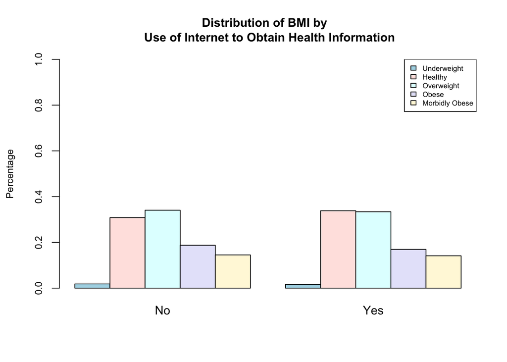

```r
# Plot of BMI by outcome groups
colors<-c("lightblue", "mistyrose", "lightcyan", "lavender","cornsilk")
barplot(a, beside=TRUE, main="Distribution of BMI by  \n Use of Internet to Obtain Health Information", ylab="Percentage", ylim=c(0.0, 1.0), cex.lab=0.8, cex.main=1.0, cex.axis=0.8, col=colors, space=NULL)
legend("topright", legend=c("Underweight", "Healthy", "Overweight", "Obese", "Morbidly Obese"), fill=colors, cex=0.6)
```

```r
# Chi-squared test
svychisq(~outcome+bmicat, design=nhissvy)
```

```
##
##  Pearson's X^2: Rao & Scott adjustment
##
## data:  svychisq(~outcome + bmicat, design = nhissvy)
## F = 5.4697, ndf = 3.9147, ddf = 1174.4000, p-value = 0.0002605
```

```r
# Education level
a<-svyby( ~educ1, ~outcome, nhissvy, svymean, na.rm=TRUE)
a
```

```
##     outcome educ1Less than High School educ1High School/GED educ1Associate
## No       No                 0.20022174            0.3241349      0.2739403
## Yes     Yes                 0.04794587            0.1739815      0.3393861
##     educ1Bachelor educ1Graduate Degree se.educ1Less than High School
## No      0.1313269           0.07037614                   0.004007209
## Yes     0.2707652           0.16792135                   0.002486016
##     se.educ1High School/GED se.educ1Associate se.educ1Bachelor
## No              0.004841930       0.004496804       0.00355976
## Yes             0.004851289       0.005819941       0.00501142
##     se.educ1Graduate Degree
## No              0.002670410
## Yes             0.004219101
```

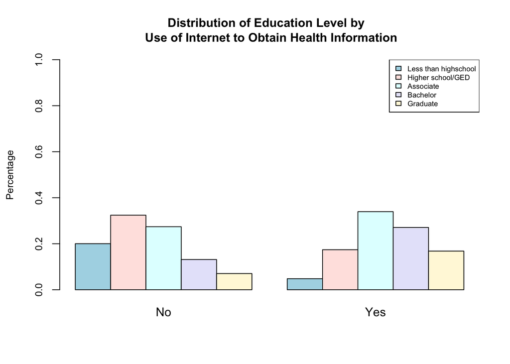

```r
# Plot of education level by outcome groups
colors<-c("lightblue", "mistyrose", "lightcyan", "lavender","cornsilk")
barplot(a, beside=TRUE, main="Distribution of Education Level by  \n Use of Internet to Obtain Health Information", ylab="Percentage", ylim=c(0.0, 1.0), cex.lab=0.8, cex.main=1.0, cex.axis=0.8, col=colors, space=NULL)
legend("topright", legend=c("Less than highschool", "Higher school/GED", "Associate", "Bachelor", "Graduate"), fill=colors, cex=0.6)
```

```r
# Chi-squared test
svychisq(~outcome+educ1, design=nhissvy)
```

```
##
##  Pearson's X^2: Rao & Scott adjustment
##
## data:  svychisq(~outcome + educ1, design = nhissvy)
## F = 493.75, ndf = 3.9463, ddf = 1183.9000, p-value < 2.2e-16
```

```r
# General health status
a<-svyby( ~phstat, ~outcome, nhissvy, svymean, na.rm=TRUE)
a
```

```
##     outcome phstatExcellent phstatVery Good phstatGood phstatFair
## No       No       0.2630170       0.2955561  0.2829203 0.11845075
## Yes     Yes       0.3054478       0.3552666  0.2442522 0.07498484
##     phstatPoor se.phstatExcellent se.phstatVery Good se.phstatGood
## No  0.04005574        0.004460486        0.004876256   0.003988730
## Yes 0.02004856        0.005288522        0.005434533   0.004394212
##     se.phstatFair se.phstatPoor
## No    0.002958309   0.002023392
## Yes   0.003168067   0.001519949
```

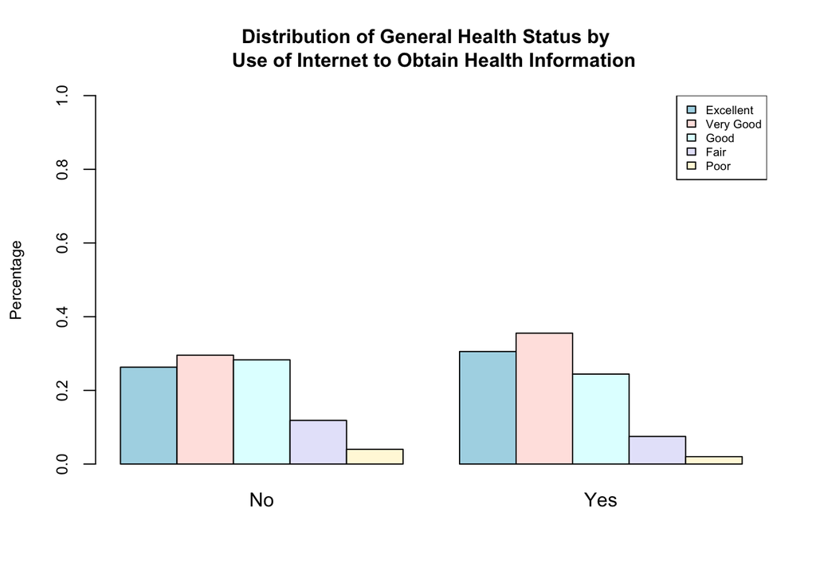

```r
# Plot of general health status by outcome groups
colors<-c("lightblue", "mistyrose", "lightcyan", "lavender","cornsilk")
barplot(a, beside=TRUE, main="Distribution of General Health Status by  \n Use of Internet to Obtain Health Information", ylab="Percentage", ylim=c(0.0, 1.0), cex.lab=0.8, cex.main=1.0, cex.axis=0.8, col=colors, space=NULL)
legend("topright", legend=c("Excellent", "Very Good", "Good ", "Fair", "Poor"), fill=colors, cex=0.6)
```

```r
# Chi-squared test
svychisq(~outcome+phstat, design=nhissvy)
```

```
##
##  Pearson's X^2: Rao & Scott adjustment
##
## data:  svychisq(~outcome + phstat, design = nhissvy)
## F = 62.588, ndf = 3.8563, ddf = 1156.9000, p-value < 2.2e-16
```

Of 36,697 adults who completed the adult sample survey, 34,365 (93.6%) subjects with completed information on all variables of interest were included in this analysis. A total of 43.49% of all participants reported use of Internet to obtain health information in the past 12 months. Among all participants, 41.01% reported use of Internet to look up health information only, 0.16% only reported use of online chat groups to learn about health topics, and 2.31% reported answered yes to both questions. From the bar plots of the raw distribitions of independent variables by groups of subjects who used Internet to obtain health information versus those who did not, there were notable differences between the distributions of covariates within the two groups, especially for smoking status, alcohol drinkng status, age group, marital status, education level and general health status. The Chi squared tests suggested significant differences (p<0.05) in the weighted percentages of each categories of independent variables between participants who used Internet to obtain health information and those who did not.

```r
## Univariate analysis - perform simple logistic regression on each variable
# Univariate analysis for each covariates
# Age groups
exp(summary(svyglm(outcome ~ factor(agecat),family=quasibinomial, design=nhissvy, na.action=na.omit))$coefficient)
```

```
##                      Estimate Std. Error      t value Pr(>|t|)
## (Intercept)         0.9689964   1.022950 2.495721e-01 1.180776
## factor(agecat)46-65 0.8566749   1.031074 6.376023e-03 1.000001
## factor(agecat)65+   0.4034882   1.039586 7.029854e-11 1.000000
```

```r
glm.1<-svyglm(outcome ~ factor(agecat),family=quasibinomial, design=nhissvy, na.action=na.omit)
# Crude OR
exp(confint(glm.1))
```

```
##                         2.5 %    97.5 %
## (Intercept)         0.9268472 1.0130625
## factor(agecat)46-65 0.8068040 0.9096285
## factor(agecat)65+   0.3739253 0.4353883
```

```r
# Gender
exp(summary(svyglm(outcome ~ factor(sex),family=quasibinomial, design=nhissvy, na.action=na.omit))$coefficient)
```

```
##                      Estimate Std. Error      t value Pr(>|t|)
## (Intercept)         0.6279791   1.024127 3.346809e-09        1
## factor(sex)2 Female 1.4480280   1.029057 4.103645e+05        1
```

```r
glm.2<-svyglm(outcome ~ factor(sex),family=quasibinomial, design=nhissvy, na.action=na.omit)
# Crude OR
exp(confint(glm.2))
```

```
##                         2.5 %    97.5 %
## (Intercept)         0.5993111 0.6580184
## factor(sex)2 Female 1.3689770 1.5316437
```

```r
# Marital status
exp(summary(svyglm(outcome ~ factor(r_maritl),family=quasibinomial, design=nhissvy, na.action=na.omit))$coefficient)
```

```
##                                              Estimate Std. Error
## (Intercept)                                 0.7531890   1.038263
## factor(r_maritl)Married/Living with Partner 1.1724363   1.043741
## factor(r_maritl)Divorced/Seperated          0.9041647   1.053555
## factor(r_maritl)Widowed                     0.3184890   1.077273
##                                                  t value Pr(>|t|)
## (Intercept)                                 5.268651e-04 1.000000
## factor(r_maritl)Married/Living with Partner 4.109493e+01 1.000242
## factor(r_maritl)Divorced/Seperated          1.449959e-01 1.055937
## factor(r_maritl)Widowed                     2.108981e-07 1.000000
```

```r
glm.3<-svyglm(outcome ~ factor(r_maritl),family=quasibinomial, design=nhissvy, na.action=na.omit)
# Crude OR
exp(confint(glm.3))
```

```
##                                                 2.5 %    97.5 %
## (Intercept)                                 0.6997492 0.8107099
## factor(r_maritl)Married/Living with Partner 1.0780719 1.2750604
## factor(r_maritl)Divorced/Seperated          0.8162816 1.0015096
## factor(r_maritl)Widowed                     0.2752564 0.3685118
```

```r
# Region
exp(summary(svyglm(outcome ~ factor(region),family=quasibinomial, design=nhissvy, na.action=na.omit))$coefficient)
```

```
##                          Estimate Std. Error     t value Pr(>|t|)
## (Intercept)             0.7725953   1.042486 0.002027902 1.000000
## factor(region)2 Midwest 1.1051670   1.053686 6.767884264 1.058459
## factor(region)3 South   0.8698951   1.053829 0.070056175 1.008310
## factor(region)4 West    1.1122645   1.054001 7.561316631 1.044945
```

```r
glm.4<-svyglm(outcome ~ factor(region),family=quasibinomial, design=nhissvy, na.action=na.omit)
# Crude OR
exp(confint(glm.4))
```

```
##                             2.5 %    97.5 %
## (Intercept)             0.7120909 0.8382407
## factor(region)2 Midwest 0.9975047 1.2244493
## factor(region)3 South   0.7849436 0.9640405
## factor(region)4 West    1.0033231 1.2330347
```

```r
# Race/Ethnicity
exp(summary(svyglm(outcome ~ factor(racerpi2),family=quasibinomial, design=nhissvy, na.action=na.omit))$coefficient)
```

```
##                                                Estimate Std. Error
## (Intercept)                                   0.8260546   1.019041
## factor(racerpi2)Black/Aferican American       0.6039334   1.042809
## factor(racerpi2)American Indian Alaska Native 0.5005720   1.170708
## factor(racerpi2)Asian                         0.7825909   1.066046
## factor(racerpi2)Multiple race/Other           1.1096845   1.122688
##                                                    t value Pr(>|t|)
## (Intercept)                                   3.981319e-05 1.000000
## factor(racerpi2)Black/Aferican American       5.959974e-06 1.000000
## factor(racerpi2)American Indian Alaska Native 1.239282e-02 1.000016
## factor(racerpi2)Asian                         2.164409e-02 1.000155
## factor(racerpi2)Multiple race/Other           2.457964e+00 1.446586
```

```r
glm.5<-svyglm(outcome ~ factor(racerpi2),family=quasibinomial, design=nhissvy, na.action=na.omit)
# Crude OR
exp(confint(glm.5))
```

```
##                                                   2.5 %    97.5 %
## (Intercept)                                   0.7960743 0.8571640
## factor(racerpi2)Black/Aferican American       0.5562992 0.6556464
## factor(racerpi2)American Indian Alaska Native 0.3675442 0.6817475
## factor(racerpi2)Asian                         0.6903912 0.8871036
## factor(racerpi2)Multiple race/Other           0.8844919 1.3922114
```

```r
# BMI
exp(summary(svyglm(outcome ~ factor(bmicat),family=quasibinomial, design=nhissvy, na.action=na.omit))$coefficient)
```

```
##                               Estimate Std. Error    t value Pr(>|t|)
## (Intercept)                  0.7034633   1.121867 0.04694573 1.002429
## factor(bmicat)healthy        1.2006285   1.128235 4.55146980 1.139655
## factor(bmicat)overweight     1.0725971   1.122215 1.83639991 1.722508
## factor(bmicat)obese          0.9884296   1.127705 0.90770731 2.516639
## factor(bmicat)morbidly_obese 1.0651013   1.129293 1.67984595 1.830073
```

```r
glm.6<-svyglm(outcome ~ factor(bmicat),family=quasibinomial, design=nhissvy, na.action=na.omit)
# Crude OR
exp(confint(glm.6))
```

```
##                                  2.5 %    97.5 %
## (Intercept)                  0.5615111 0.8813016
## factor(bmicat)healthy        0.9477805 1.5209311
## factor(bmicat)overweight     0.8556364 1.3445716
## factor(bmicat)obese          0.7809882 1.2509703
## factor(bmicat)morbidly_obese 0.8392509 1.3517301
```

```r
# Education level
exp(summary(svyglm(outcome ~ factor(educ1),family=quasibinomial, design=nhissvy, na.action=na.omit))$coefficient)
```

```
##                               Estimate Std. Error      t value Pr(>|t|)
## (Intercept)                  0.1854913   1.057043 6.466986e-14        1
## factor(educ1)High School/GED 2.2414924   1.066783 2.644236e+05        1
## factor(educ1)Associate       5.1736631   1.064625 2.502570e+11        1
## factor(educ1)Bachelor        8.6099195   1.067922 1.691356e+14        1
## factor(educ1)Graduate Degree 9.9641559   1.073624 1.133947e+14        1
```

```r
glm.7<-svyglm(outcome ~ factor(educ1),family=quasibinomial, design=nhissvy, na.action=na.omit)
# Crude OR
exp(confint(glm.7))
```

```
##                                  2.5 %     97.5 %
## (Intercept)                  0.1663808  0.2067969
## factor(educ1)High School/GED 1.9747374  2.5442817
## factor(educ1)Associate       4.5760796  5.8492841
## factor(educ1)Bachelor        7.5694259  9.7934394
## factor(educ1)Graduate Degree 8.6690403 11.4527560
```

```r
# General health status
exp(summary(svyglm(outcome ~ factor(phstat),family=quasibinomial, design=nhissvy, na.action=na.omit))$coefficient)
```

```
##                          Estimate Std. Error      t value Pr(>|t|)
## (Intercept)             0.8935547   1.029669 2.129099e-02 1.000145
## factor(phstat)Very Good 1.0350498   1.042697 2.279475e+00 1.507774
## factor(phstat)Good      0.7433976   1.037625 3.260923e-04 1.000000
## factor(phstat)Fair      0.5451079   1.061562 3.881965e-05 1.000000
## factor(phstat)Poor      0.4309880   1.096854 1.111682e-04 1.000000
```

```r
glm.8<-svyglm(outcome ~ factor(phstat),family=quasibinomial, design=nhissvy, na.action=na.omit)
# Crude OR
exp(confint(glm.8))
```

```
##                             2.5 %    97.5 %
## (Intercept)             0.8437900 0.9462543
## factor(phstat)Very Good 0.9536129 1.1234413
## factor(phstat)Good      0.6914842 0.7992084
## factor(phstat)Fair      0.4848756 0.6128225
## factor(phstat)Poor      0.3595627 0.5166015
```

```r
# Univariate analysis - Exposure of interest
# Smoking status
exp(summary(svyglm(outcome ~ factor(smkstat2),family=quasibinomial, design=nhissvy, na.action=na.omit))$coefficient)
```

```
##                                           Estimate Std. Error      t value
## (Intercept)                              0.7820229   1.019302 2.597738e-06
## factor(smkstat2)former smoker            1.1278991   1.034777 3.380624e+01
## factor(smkstat2)current some day smoker  0.8994755   1.075690 2.340969e-01
## factor(smkstat2)current every day smoker 0.7317229   1.057407 3.713598e-03
##                                          Pr(>|t|)
## (Intercept)                              1.000000
## factor(smkstat2)former smoker            1.000498
## factor(smkstat2)current some day smoker  1.158993
## factor(smkstat2)current every day smoker 1.000000
```

```r
glm.smk<-svyglm(outcome ~ factor(smkstat2),family=quasibinomial, design=nhissvy, na.action=na.omit)
# Crude OR
exp(confint(glm.smk))
```

```
##                                              2.5 %    97.5 %
## (Intercept)                              0.7532626 0.8118813
## factor(smkstat2)former smoker            1.0548023 1.2060613
## factor(smkstat2)current some day smoker  0.7796206 1.0377563
## factor(smkstat2)current every day smoker 0.6558927 0.8163201
```

```r
# Alcohol drinking status
exp(summary(svyglm(outcome ~ factor(alcstat2),family=quasibinomial, design=nhissvy, na.action=na.omit))$coefficient)
```

```
##                                                   Estimate Std. Error
## (Intercept)                                      0.4142007   1.039636
## factor(alcstat2)Former drinker                   1.2704647   1.059757
## factor(alcstat2)Current infrequent-light drinker 2.4178245   1.045955
## factor(alcstat2)Current moderate-heavier drinker 2.5067418   1.054941
##                                                       t value Pr(>|t|)
## (Intercept)                                      1.419980e-10 1.000000
## factor(alcstat2)Former drinker                   6.183664e+01 1.000048
## factor(alcstat2)Current infrequent-light drinker 3.418340e+08 1.000000
## factor(alcstat2)Current moderate-heavier drinker 2.898474e+07 1.000000
```

```r
glm.alc<-svyglm(outcome ~ factor(alcstat2),family=quasibinomial, design=nhissvy, na.action=na.omit)
# Crude OR
exp(confint(glm.alc))
```

```
##                                                      2.5 %   97.5 %
## (Intercept)                                      0.3838167 0.446990
## factor(alcstat2)Former drinker                   1.1338601 1.423527
## factor(alcstat2)Current infrequent-light drinker 2.2140134 2.640397
## factor(alcstat2)Current moderate-heavier drinker 2.2572705 2.783784
```

```r
## load ggplot2 package
library(ggplot2)

## Multivariate analysis controlling for covariates
## Fit a model with all the covariates
glm.cov <- svyglm(outcome ~ factor(agecat) + factor(sex) + factor(r_maritl) + factor (region) + factor(racerpi2) + factor(bmicat) + factor(educ1) + factor(phstat),family=quasibinomial, design=nhissvy, na.action=na.omit)

summary(svyglm(outcome ~ factor(agecat) + factor(sex) + factor(r_maritl) + factor (region) + factor(racerpi2) + factor(bmicat) + factor(educ1) + factor(phstat),family=quasibinomial, design=nhissvy, na.action=na.omit))
```

```
##
## Call:
## svyglm(formula = outcome ~ factor(agecat) + factor(sex) + factor(r_maritl) +
##     factor(region) + factor(racerpi2) + factor(bmicat) + factor(educ1) +
##     factor(phstat), family = quasibinomial, design = nhissvy,
##     na.action = na.omit)
##
## Survey design:
## svydesign(id = ~psu_p, strata = ~strat_p, nest = TRUE, weights = ~wtia_sa,
##     data = my.data)
##
## Coefficients:
##                                                Estimate Std. Error t value
## (Intercept)                                   -1.953191   0.155642 -12.549
## factor(agecat)46-65                           -0.166666   0.035550  -4.688
## factor(agecat)65+                             -0.758883   0.046488 -16.324
## factor(sex)2 Female                            0.496042   0.034084  14.554
## factor(r_maritl)Married/Living with Partner    0.172324   0.046775   3.684
## factor(r_maritl)Divorced/Seperated            -0.019356   0.060589  -0.319
## factor(r_maritl)Widowed                       -0.650044   0.087550  -7.425
## factor(region)2 Midwest                        0.107198   0.056561   1.895
## factor(region)3 South                         -0.065399   0.055661  -1.175
## factor(region)4 West                           0.118774   0.057012   2.083
## factor(racerpi2)Black/Aferican American       -0.390782   0.045695  -8.552
## factor(racerpi2)American Indian Alaska Native -0.424967   0.179266  -2.371
## factor(racerpi2)Asian                         -0.620276   0.075467  -8.219
## factor(racerpi2)Multiple race/Other            0.105393   0.124133   0.849
## factor(bmicat)healthy                          0.012614   0.136691   0.092
## factor(bmicat)overweight                       0.056360   0.131824   0.428
## factor(bmicat)obese                            0.007752   0.137018   0.057
## factor(bmicat)morbidly_obese                   0.057676   0.136512   0.422
## factor(educ1)High School/GED                   0.850013   0.066140  12.852
## factor(educ1)Associate                         1.636128   0.065684  24.909
## factor(educ1)Bachelor                          2.162640   0.067301  32.134
## factor(educ1)Graduate Degree                   2.391894   0.076901  31.104
## factor(phstat)Very Good                        0.197419   0.046010   4.291
## factor(phstat)Good                             0.140028   0.041511   3.373
## factor(phstat)Fair                             0.173437   0.065898   2.632
## factor(phstat)Poor                            -0.063510   0.096762  -0.656
##                                               Pr(>|t|)
```

[output cut: 17 more lines]

```
## factor(bmicat)morbidly_obese                  0.672991
## factor(educ1)High School/GED                   < 2e-16 ***
## factor(educ1)Associate                         < 2e-16 ***
## factor(educ1)Bachelor                          < 2e-16 ***
## factor(educ1)Graduate Degree                   < 2e-16 ***
## factor(phstat)Very Good                       2.47e-05 ***
## factor(phstat)Good                            0.000850 ***
## factor(phstat)Fair                            0.008971 **
## factor(phstat)Poor                            0.512143
## ---
## Signif. codes:  0 '***' 0.001 '**' 0.01 '*' 0.05 '.' 0.1 ' ' 1
##
## (Dispersion parameter for quasibinomial family taken to be 0.98996)
##
## Number of Fisher Scoring iterations: 4
```

```r
# Adjusted ORs
exp(summary(svyglm(outcome ~  factor(agecat) + factor(sex) + factor(r_maritl) + factor (region) + factor(racerpi2) + factor(bmicat) + factor(educ1) + factor(phstat),family=quasibinomial, design=nhissvy, na.action=na.omit))$coefficient)
```

```
##                                                 Estimate Std. Error
## (Intercept)                                    0.1418207   1.168407
## factor(agecat)46-65                            0.8464819   1.036190
## factor(agecat)65+                              0.4681893   1.047585
## factor(sex)2 Female                            1.6422092   1.034671
## factor(r_maritl)Married/Living with Partner    1.1880631   1.047886
## factor(r_maritl)Divorced/Seperated             0.9808306   1.062462
## factor(r_maritl)Widowed                        0.5220229   1.091497
## factor(region)2 Midwest                        1.1131550   1.058191
## factor(region)3 South                          0.9366936   1.057240
## factor(region)4 West                           1.1261149   1.058669
## factor(racerpi2)Black/Aferican American        0.6765274   1.046756
## factor(racerpi2)American Indian Alaska Native  0.6537915   1.196339
## factor(racerpi2)Asian                          0.5377963   1.078387
## factor(racerpi2)Multiple race/Other            1.1111475   1.132166
## factor(bmicat)healthy                          1.0126938   1.146473
## factor(bmicat)overweight                       1.0579785   1.140908
## factor(bmicat)obese                            1.0077819   1.146848
## factor(bmicat)morbidly_obese                   1.0593718   1.146269
## factor(educ1)High School/GED                   2.3396768   1.068376
## factor(educ1)Associate                         5.1352488   1.067889
## factor(educ1)Bachelor                          8.6940606   1.069617
## factor(educ1)Graduate Degree                  10.9341795   1.079935
## factor(phstat)Very Good                        1.2182542   1.047084
## factor(phstat)Good                             1.1503056   1.042385
## factor(phstat)Fair                             1.1893854   1.068118
## factor(phstat)Poor                             0.9384644   1.101598
##                                                    t value Pr(>|t|)
## (Intercept)                                   3.547421e-06 1.000000
## factor(agecat)46-65                           9.203535e-03 1.000004
## factor(agecat)65+                             8.135966e-08 1.000000
## factor(sex)2 Female                           2.092138e+06 1.000000
## factor(r_maritl)Married/Living with Partner   3.980959e+01 1.000276
## factor(r_maritl)Divorced/Seperated            7.265437e-01 2.116202
## factor(r_maritl)Widowed                       5.962541e-04 1.000000
## factor(region)2 Midwest                       6.654385e+00 1.060886
## factor(region)3 South                         3.088357e-01 1.272563
## factor(region)4 West                          8.030959e+00 1.038884
## factor(racerpi2)Black/Aferican American       1.931818e-04 1.000000
## factor(racerpi2)American Indian Alaska Native 9.342489e-02 1.018620
## factor(racerpi2)Asian                         2.694301e-04 1.000000
## factor(racerpi2)Multiple race/Other           2.337393e+00 1.486761
## factor(bmicat)healthy                         1.096673e+00 2.525760
## factor(bmicat)overweight                      1.533481e+00 1.952910
## factor(bmicat)obese                           1.058206e+00 2.598475
## factor(bmicat)morbidly_obese                  1.525769e+00 1.960092
## factor(educ1)High School/GED                  3.814392e+05 1.000000
## factor(educ1)Associate                        6.575441e+10 1.000000
## factor(educ1)Bachelor                         9.028746e+13 1.000000
## factor(educ1)Graduate Degree                  3.221881e+13 1.000000
## factor(phstat)Very Good                       7.302595e+01 1.000025
## factor(phstat)Good                            2.917281e+01 1.000850
## factor(phstat)Fair                            1.389996e+01 1.009011
## factor(phstat)Poor                            5.187371e-01 1.668863
```

```r
# Calculate CIs
exp(confint(glm.cov))
```

```
##                                                   2.5 %     97.5 %
## (Intercept)                                   0.1045340  0.1924075
## factor(agecat)46-65                           0.7895090  0.9075661
## factor(agecat)65+                             0.4274164  0.5128518
## factor(sex)2 Female                           1.5360893  1.7556603
## factor(r_maritl)Married/Living with Partner   1.0839881  1.3021304
## factor(r_maritl)Divorced/Seperated            0.8710049  1.1045043
## factor(r_maritl)Widowed                       0.4397107  0.6197437
## factor(region)2 Midwest                       0.9963479  1.2436561
## factor(region)3 South                         0.8398825  1.0446639
## factor(region)4 West                          1.0070567  1.2592487
## factor(racerpi2)Black/Aferican American       0.6185706  0.7399144
## factor(racerpi2)American Indian Alaska Native 0.4600955  0.9290316
## factor(racerpi2)Asian                         0.4638531  0.6235267
## factor(racerpi2)Multiple race/Other           0.8711835  1.4172087
## factor(bmicat)healthy                         0.7746881  1.3238214
## factor(bmicat)overweight                      0.8170866  1.3698899
## factor(bmicat)obese                           0.7704368  1.3182449
## factor(bmicat)morbidly_obese                  0.8106795  1.3843555
## factor(educ1)High School/GED                  2.0552154  2.6635105
## factor(educ1)Associate                        4.5149340  5.8407897
## factor(educ1)Bachelor                         7.6196716  9.9199406
## factor(educ1)Graduate Degree                  9.4043332 12.7128930
## factor(phstat)Very Good                       1.1132032  1.3332186
## factor(phstat)Good                            1.0604219  1.2478080
## factor(phstat)Fair                            1.0452734  1.3533661
## factor(phstat)Poor                            0.7763436  1.1344401
```

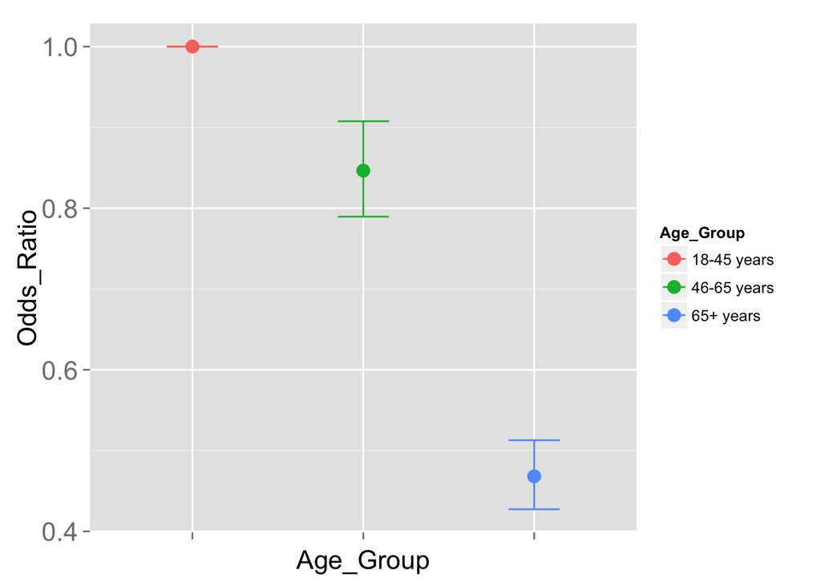

```r
## Plot adjusted OR for age groups with 95% CI
df<-data.frame(Age_Group=c("18-45 years", "46-65 years", "65+ years"), Odds_Ratio=c(1, 0.8464819, 0.4681893), L=c(1, 0.7895090, 0.4274164), U=c(1, 0.9075661, 0.5128518))
ggplot(df, aes(x=Age_Group, ordered=TRUE, y=Odds_Ratio, color=Age_Group)) + geom_point(size=4) + geom_errorbar(aes(ymax=U, ymin=L, width=0.3)) +theme(axis.text.x=element_blank(), axis.text.y=element_text(size=16), axis.title.x=element_text(size=16), axis.title.y=element_text(size=16))
```

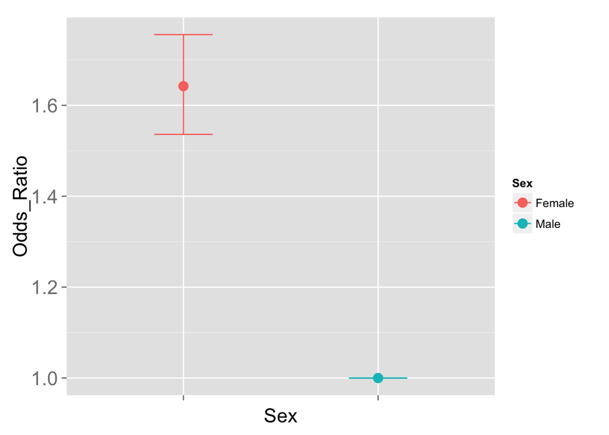

```r
## Plot adjusted OR for gender with 95% CI
df<-data.frame(Sex=c("Male", "Female"), Odds_Ratio=c(1, 1.6422092), L=c(1, 1.5360893), U=c(1,1.7556603))
ggplot(df, aes(x=Sex, ordered=TRUE, y=Odds_Ratio, color=Sex)) + geom_point(size=4) + geom_errorbar(aes(ymax=U, ymin=L, width=0.3)) +theme(axis.text.x=element_blank(), axis.text.y=element_text(size=16), axis.title.x=element_text(size=16), axis.title.y=element_text(size=16))
```

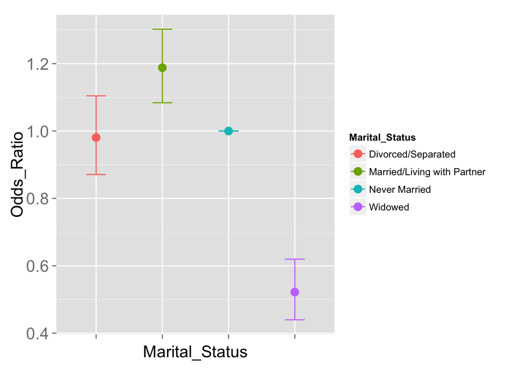

```r
## Plot adjusted OR for marital status with 95% CI
df<-data.frame(Marital_Status=c("Never Married", "Married/Living with Partner", "Divorced/Separated", "Widowed"), Odds_Ratio=c(1, 1.1880631, 0.9808306, 0.5220229), L=c(1, 1.0839881, 0.8710049, 0.4397107), U=c(1,1.3021304, 1.1045043, 0.6197437))
ggplot(df, aes(x=Marital_Status,ordered=TRUE, y=Odds_Ratio, color=Marital_Status)) + geom_point(size=4) + geom_errorbar(aes(ymax=U, ymin=L, width=0.3)) +theme(axis.text.x=element_blank(), axis.text.y=element_text(size=16), axis.title.x=element_text(size=16), axis.title.y=element_text(size=16))
```

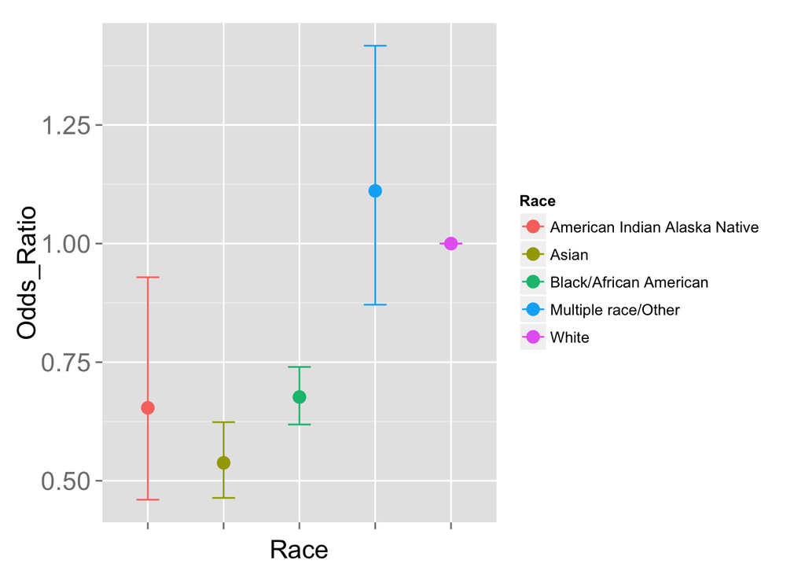

```r
## Plot adjusted OR for Race with 95% CI
df<-data.frame(Race=c("White","Black/African American", "American Indian Alaska Native", "Asian", "Multiple race/Other"), Odds_Ratio=c(1, 0.6765274, 0.6537915, 0.5377963, 1.1111475), L=c(1, 0.6185706, 0.4600955, 0.4638531, 0.8711835), U=c(1, 0.7399144, 0.9290316, 0.6235267, 1.4172087))
ggplot(df, aes(x=Race,ordered=TRUE, y=Odds_Ratio, color=Race)) + geom_point(size=4) + geom_errorbar(aes(ymax=U, ymin=L, width=0.3)) +theme(axis.text.x=element_blank(), axis.text.y=element_text(size=16), axis.title.x=element_text(size=16), axis.title.y=element_text(size=16))
```

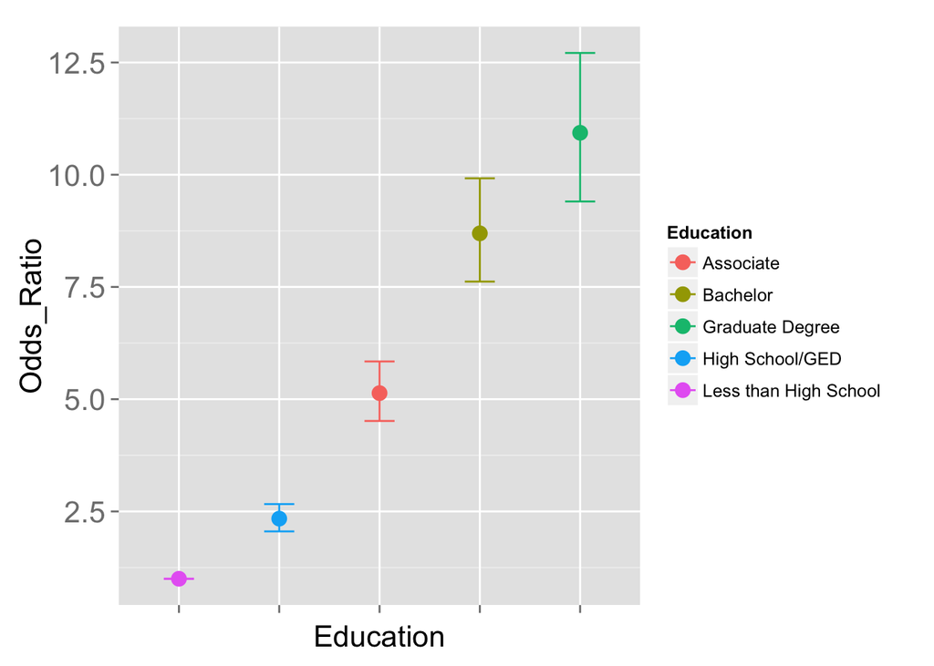

```r
## Plot adjusted OR for education level with 95% CI
edulevels<-c("Less than High School","High School/GED", "Associate", "Bachelor", "Graduate Degree")
df<-data.frame(Education=c("Less than High School","High School/GED", "Associate", "Bachelor", "Graduate Degree"), Odds_Ratio=c(1, 2.3396768, 5.1352488, 8.6940606, 10.9341795), L=c(1, 2.0552154, 4.5149340, 7.6196716, 9.4043332), U=c(1, 2.6635105, 5.8407897, 9.9199406, 12.7128930))
ggplot(df, aes(x=Education, y=Odds_Ratio, color=Education)) + scale_x_discrete(limits=edulevels)+ geom_point(size=4) + geom_errorbar(aes(ymax=U, ymin=L, width=0.3)) +theme(axis.text.x=element_blank(), axis.text.y=element_text(size=16), axis.title.x=element_text(size=16), axis.title.y=element_text(size=16))
```